# Chapter 25 - Visualization with Matplotlib

We will study how to use `matplotlib` to generate data visualizations.

```python
# %pip install matplotlib seaborn scikit-learn
```

## Matplotlib shorthands

We will use the following aliases for matplotlib (`mpl`) and its MATLAB-style interface called Pyplot (`plt`).

```python
import matplotlib as mpl
import matplotlib.pyplot as plt
```

## Setting styles

```python
plt.style.use('classic')
```

## A first plot

We will use `plt.show()` from within a script to display a plot. In IPython and Jupyter, you do not need to call `plt.show()`.

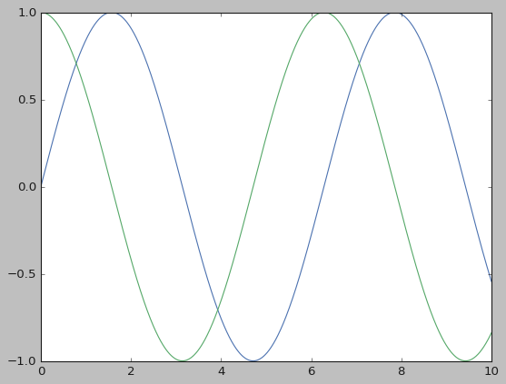

```python
import numpy as np

x = np.linspace(0, 10, 1000)

plt.plot(x, np.sin(x))
plt.plot(x, np.cos(x))
plt.show()
```

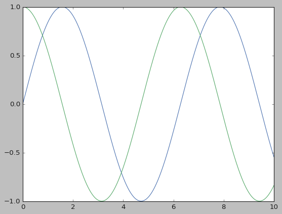

```python
plt.plot(x, np.sin(x))
plt.plot(x, np.cos(x));
```

## The `fig` object

You can store a plot into a figure object in matplotlib. This allows for greater control over the figure. For instance, we can save the figure to a file with:

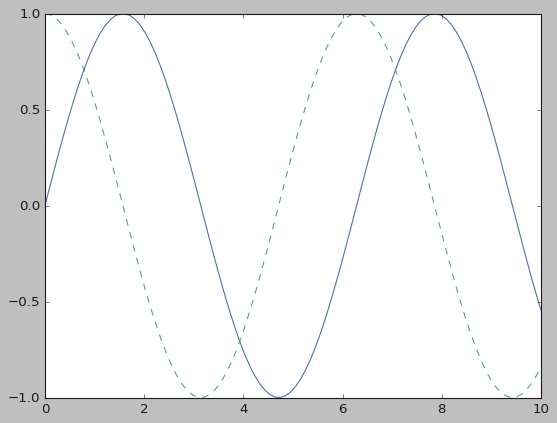

```python
x = np.linspace(0, 10, 100)

fig = plt.figure()
plt.plot(x, np.sin(x), '-')
plt.plot(x, np.cos(x), '--')
fig.savefig('my_figure.png')
```

## The Pyplot interface

A quick and convenient interface to easily generate plots.

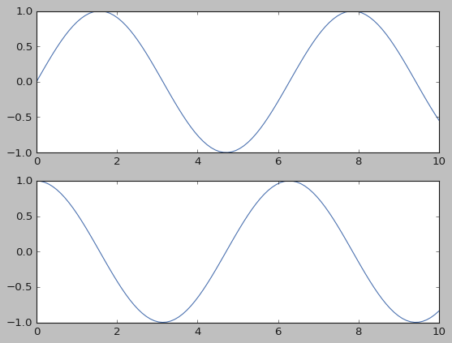

```python
plt.figure()  # create a plot figure

# create the first of two panels and set current axis
plt.subplot(2, 1, 1) # (rows, columns, panel number)
plt.plot(x, np.sin(x))

# create the second panel and set current axis
plt.subplot(2, 1, 2)
plt.plot(x, np.cos(x));
```

## The object-oriented interface

An alternative to the Pyplot interface and is more versatile, albeit more complex. It is based on the `Figure` and `Axes` objects.

For simpler plots, you should go with Pyplot. For more elaborate figures, you might want to use the object-oriented interface. In many cases,the difference between using `plt` or `ax` is minimal.

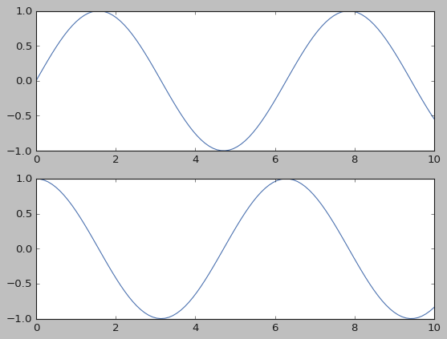

```python
# First create a grid of plots
# ax will be an array of two Axes objects
fig, ax = plt.subplots(2)

# Call plot() method on the appropriate object
ax[0].plot(x, np.sin(x))
ax[1].plot(x, np.cos(x));
```

# Chapter 26. Simple Line Plots

We will use the *seaborn whitegrid* style for the following plot. A [full list of styles](https://matplotlib.org/stable/gallery/style_sheets/style_sheets_reference.html) is available on matplotlib's website.

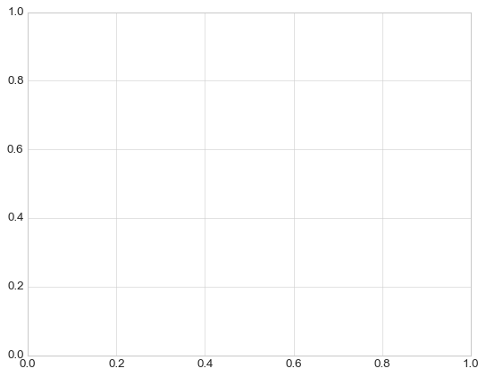

```python
plt.style.use('seaborn-v0_8-whitegrid')

# Create figure and axes
fig = plt.figure()
ax = plt.axes()
```

The `plot` method creates line plots. The following plots a simple sinusoid:

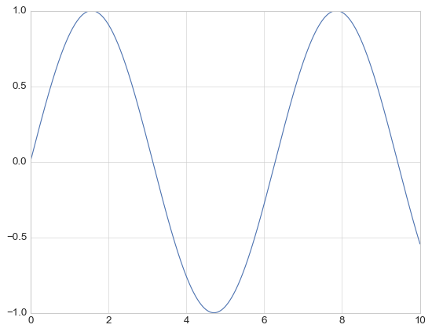

```python
x = np.linspace(0, 10, 1000)
# Create figure and axes
fig = plt.figure()
ax = plt.axes()
ax.plot(x, np.sin(x))
```

## Plotting multiple lines

Every call to `plot` creates a new line. However, this does not immediately draw the figure. All plot calls are held back until the draw operation is triggered, either by IPython or by calling `show()`.

The `color` keyword in `plt.plot` allows us to choose the color of the line.

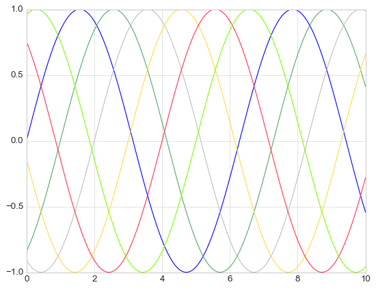

```python
plt.plot(x, np.sin(x - 0), color='blue')        # specify color by name
plt.plot(x, np.sin(x - 1), color='g')           # short color code (rgbcmyk)
plt.plot(x, np.sin(x - 2), color='0.75')        # grayscale between 0 and 1
plt.plot(x, np.sin(x - 3), color='#FFDD44')     # hex code (RRGGBB, 00 to FF)
plt.plot(x, np.sin(x - 4), color=(1.0,0.2,0.3)) # RGB tuple, values 0 to 1
plt.plot(x, np.sin(x - 5), color='chartreuse'); # HTML
```

The line style can be defined using the `linestyle` keyword in `plt.plot`:

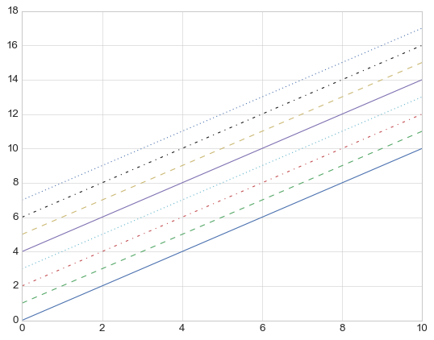

```python
plt.plot(x, x + 0, linestyle='solid')
plt.plot(x, x + 1, linestyle='dashed')
plt.plot(x, x + 2, linestyle='dashdot')
plt.plot(x, x + 3, linestyle='dotted');

# For short, you can use the following codes:
plt.plot(x, x + 4, linestyle='-')  # solid
plt.plot(x, x + 5, linestyle='--') # dashed
plt.plot(x, x + 6, linestyle='-.') # dashdot
plt.plot(x, x + 7, linestyle=':'); # dotted
```

You can use **style shorthands** by combining both line style and color into a string:

```python
plt.plot(x, x + 0, '-g')   # solid green
plt.plot(x, x + 1, '--c')  # dashed cyan
plt.plot(x, x + 2, '-.k')  # dashdot black
plt.plot(x, x + 3, ':r');  # dotted red
```

[output not shown]

## Axes limits

By default, matplotlib decides the axes limits based on the data. If you would like to manually adjust the limits, you can do so using `plt.xlim` and `plt.ylim`:

```
(-1.5, 1.5)
```

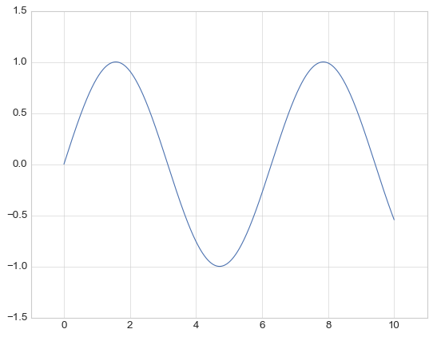

```python
plt.plot(x, np.sin(x))

plt.xlim(-1, 11)
plt.ylim(-1.5, 1.5)
```

## Plot labels

We can add titles, axis labels and legends:

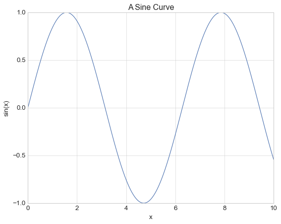

```python
plt.plot(x, np.sin(x))
plt.title("A Sine Curve")
plt.xlabel("x")
plt.ylabel("sin(x)");
```

The `;` in the code above prevents the object to be output to IPython. It does not change the functioning of the code in any other way.

Adding a legend when multiple plots/lines are present. Note that `'-g`' and `':b'` are shorthand for line styles: solid green and dotted blue, respectively.

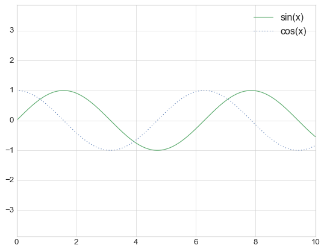

```python
plt.plot(x, np.sin(x), '-g', label='sin(x)')
plt.plot(x, np.cos(x), ':b', label='cos(x)')
plt.axis('equal')

plt.legend();
```

# Chapter 27. Simple Scatter Plots

The `plot` function can also be used to generated scatter plots by using the style option `'o'`.

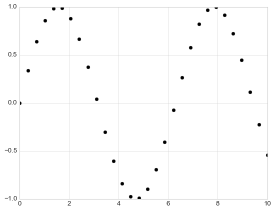

```python
x = np.linspace(0, 10, 30)
y = np.sin(x)

plt.plot(x, y, 'o', color='black');
```

You can choose different **markers** to appear in the plot:

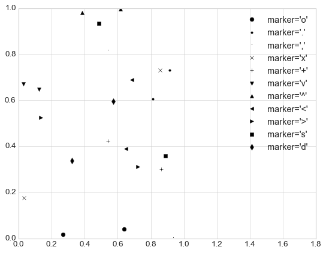

```python
rng = np.random.default_rng(0)
for marker in ['o', '.', ',', 'x', '+', 'v', '^', '<', '>', 's', 'd']:
    plt.plot(rng.random(2), rng.random(2), marker, color='black',
                label="marker='{0}'".format(marker))
plt.legend(numpoints=1, fontsize=13)
plt.xlim(0, 1.8);
```

You can customize the markers and lines in a wide range of properties.

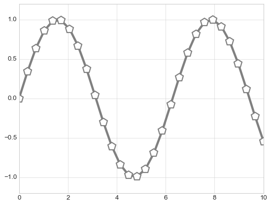

```python
plt.plot(x, y, '-p', color='gray',
                 markersize=15, linewidth=4,
                 markerfacecolor='white',
                 markeredgecolor='gray',
                 markeredgewidth=2)
plt.ylim(-1.2, 1.2);
```

## Scatter plots with `plt.scatter`

A more robust way to create scatter plots is using `plt.scatter`.

```python
plt.scatter(x, y, marker='o');
```

[output not shown]

`plt.scatter` allows you to control each marker's properties individually:

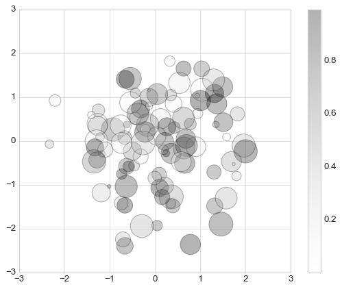

```python
rng = np.random.default_rng(0)
x = rng.normal(size=100)
y = rng.normal(size=100)
colors = rng.random(100)
sizes = 1000 * rng.random(100)

plt.scatter(x, y, c=colors, s=sizes, alpha=0.3)
plt.colorbar();  # show color scale
```

The following example uses the `iris` dataset from `sklearn`, where each sample comes from one of three different flower types with different petal size and sepal width.

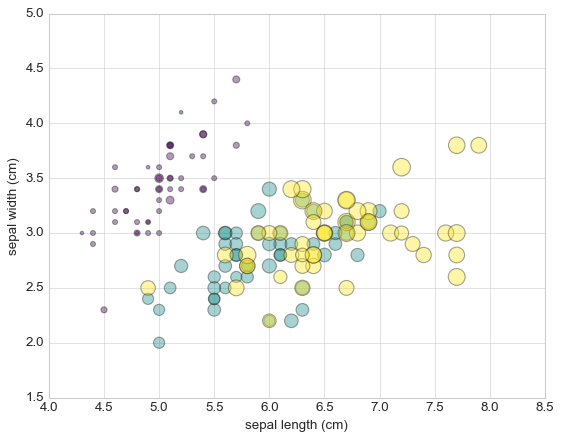

```python
from sklearn.datasets import load_iris
iris = load_iris()
features = iris.data.T

plt.scatter(features[0], features[1], alpha=0.4,
            s=100*features[3], c=iris.target, cmap='viridis')
plt.xlabel(iris.feature_names[0])
plt.ylabel(iris.feature_names[1]);
```

## Plotting errorbars

If you have an error estimate and you would like to show it besides your plot, you can use `plt.errorbar`.

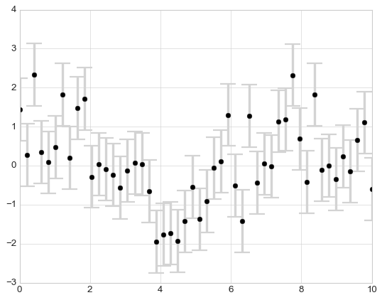

```python
x = np.linspace(0, 10, 50)
dy = 0.8
y = np.sin(x) + dy * np.random.randn(50)

plt.errorbar(x, y, yerr=dy, fmt='o', color='black',
                     ecolor='lightgray', elinewidth=3, capsize=10, capthick=2);
```

Try playing with the parameters and see what changes in the figure.

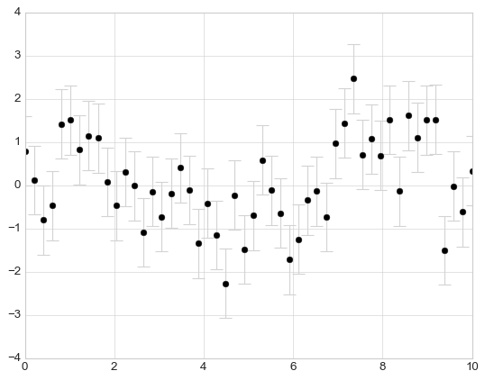

```python
dy = 0.8
y = np.sin(x) + dy * np.random.randn(50)

plt.errorbar(x, y, yerr=dy, fmt='o', color='black',
                     ecolor='lightgray', elinewidth=1, capsize=6, capthick=1);
```

# Chapter 28. Density and Contour Plots

Contour plots can be used to display three-dimensional data in two dimensions. In Pyplot this is done using `plt.contour`.

```python
# Let us define a function with two variables as follows:
def f(x, y):
            return np.sin(x) ** 10 + np.cos(10 + y * x) * np.cos(x)
```

The `plt.contour` function takes three arguments: a grid with *x*, *y* and *z* values. The *x* and *y* represent positions on the plane, the *z* values will be represented by the contour levels. You can think of it as the *height* of the plot at a point *x* and *y*.

To create this grid, we will use `np.meshgrid`.

```python
x = np.linspace(0, 5, 50)
y = np.linspace(0, 5, 40)

X, Y = np.meshgrid(x, y)
Z = f(X, Y)
```

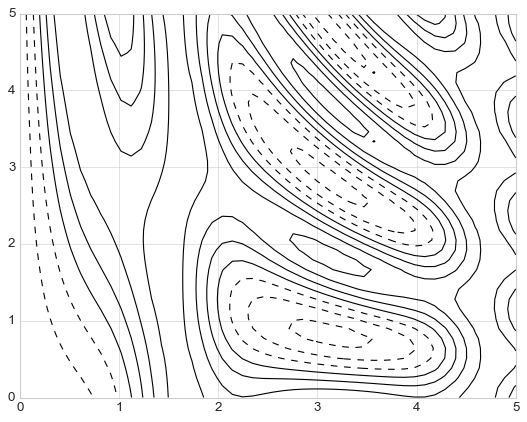

```python
plt.contour(X, Y, Z, colors='black');
```

When using a single color, negative values are represented by dashed lines and positive values by solid lines.

We can use color-coded scales with the `cmap` argument. We can also specify the numer of lines to be drawn.

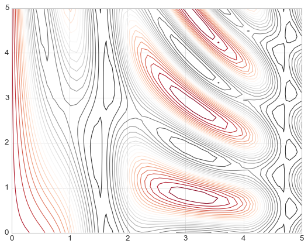

```python
plt.contour(X, Y, Z, 20, cmap='RdGy');
```

The contour is looking better, but the lines can be a bit distracting. We can use `plt.contourf` which *fills* the space between lines of a contour.

The result is similar to a heatmap, with colors indicating the values at each *(x,y)* coordinate.

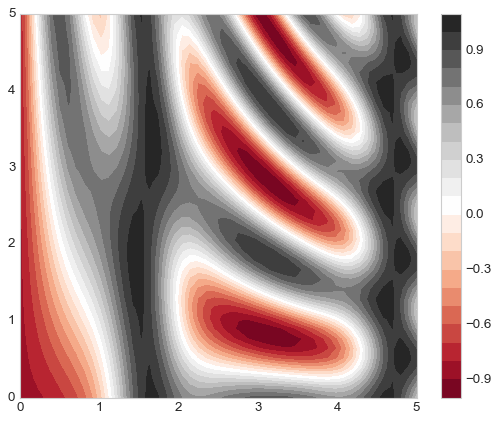

```python
plt.contourf(X, Y, Z, 20, cmap='RdGy')
plt.colorbar();
```

## Histograms, binnings and density

One of the most useful steps in understanding a dataset is looking at a histogram. The histogram will show the distribution of values for a certain variable in the data.

```python
%matplotlib inline
import numpy as np
import matplotlib.pyplot as plt
plt.style.use('ggplot')

rng = np.random.default_rng(1701)
data = rng.normal(size=1000)
```

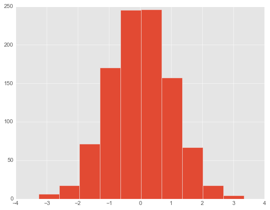

```python
plt.hist(data);
```

The `hist` function allows customization of many parameters. The following is a histogram of the same data as above with tweaked parameters.

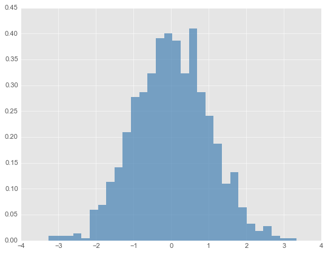

```python
plt.hist(data, bins=30, density=True, alpha=0.7,
                 histtype='stepfilled', color='steelblue',
                 edgecolor='none');
```

This histogram has some transparency, controled by `alpha`, it also uses the `stepfilled` style which creates filled rectangles for each bin.

This setup is useful when comparing multiple distributions:

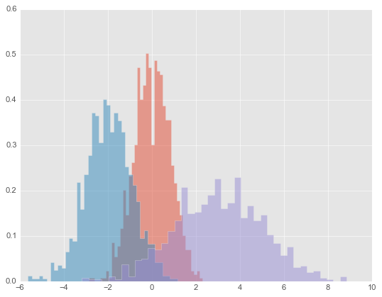

```python
x1 = rng.normal(0, 0.8, 1000)
x2 = rng.normal(-2, 1, 1000)
x3 = rng.normal(3, 2, 1000)

kwargs = dict(histtype='stepfilled', alpha=0.5, density=True, bins=40)

plt.hist(x1, **kwargs)
plt.hist(x2, **kwargs)
plt.hist(x3, **kwargs);
```

## Two-dimensional histogram

```python
# Generated 2D data
plt.style.use('ggplot')
mean = [0, 0]
cov = [[1, 1], [1, 2]]
x, y = rng.multivariate_normal(mean, cov, 10000).T
```

[figure not shown]

```python
plt.hist2d(x, y, bins=30)
cb = plt.colorbar()
cb.set_label('counts in bin')
```

Using hexagonal bins instead of squares with `plt.hexbin`.

[figure not shown]

```python
plt.hexbin(x, y, gridsize=30)
cb = plt.colorbar(label='count in bin')
```

# Chapter 36. Visualization with Seaborn

Matplotlib is a robust library for data visualization. Perhaps its major drawback is that it can be clunky when one wants to produce sophisticated plots. Moreover, it has no innate ability to integrate Pandas `DataFrame`s, which are widely used in data applications.

This is where **Seaborn** comes in. Seaborn provides an API on top of Matplotlib enabling the use of high-level function for data visualization. It also fully integrates with Pandas structures.

By convention, we import Seaborn as `sns`.

```python
%matplotlib inline
import matplotlib.pyplot as plt
import seaborn as sns
import numpy as np
import pandas as pd

sns.set_theme()  # Set plot style
```

# Seaborn plots

## Histograms, KDE, and Densities

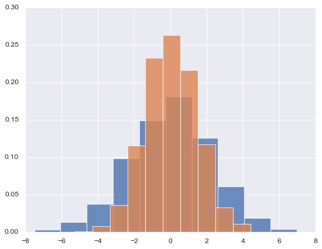

```python
# Generate random variables, compare both distributions
data = np.random.multivariate_normal([0, 0], [[5, 2], [2, 2]], size=2000)
data = pd.DataFrame(data, columns=['x', 'y'])

# Plot a histogram of both 'x' and 'y'
for col in 'xy':
    plt.hist(data[col], density=True, alpha=0.8)
```

A histogram will show bins as discrete (step) intervals. A **kernel density estimation** (KDE) is a smoothened estimate of the distribution. It is reasonable to use a KDE if your data is assumed to be continuous.

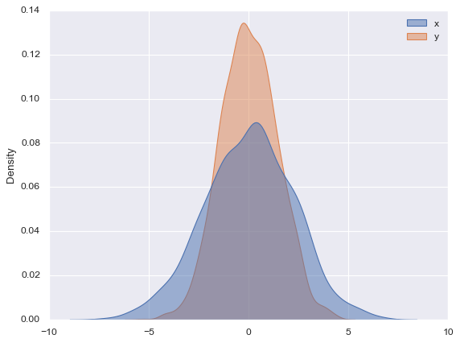

```python
sns.kdeplot(data=data, fill=True, alpha=0.5);
```

Note how Seaborn automatically figured out that your `data` contains two distributions in columns 'x' and 'y'.

If we pass arguments `x` and `y` to `kdeplot`, we can a two-dimensional KDE. Note that `x` and `y` are the *name* of the arguments, coincidentally equal to the data columns in this example.

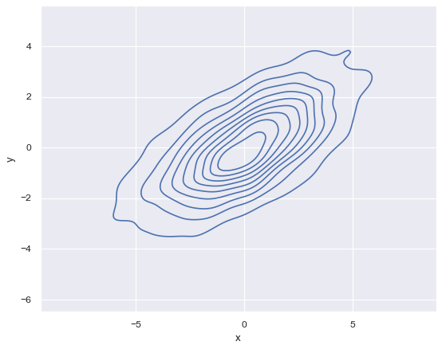

```python
sns.kdeplot(data=data, x='x', y='y');
```